# R Notebook

# ANEXO 1: Desarrollo de Regresión y Diagnosticos

## LIMPIEZA:

```
## tibble [178 × 4] (S3: tbl_df/tbl/data.frame)
##  $ Gasto_Educación   : num [1:178] 3.2 3.9 6.1 1.8 3.3 4.8 2.7 5.1 5.2 2.7 ...
##  $ Maestros_cap_pri  : num [1:178] 68 90 100 47 53 67 75 42 NA 100 ...
##  $ Tasa_finalizar_pri: num [1:178] 84 101 104 46 96 99 93 88 99 100 ...
##  $ PAISES            : chr [1:178] "Afghanistan" "Albania" "Algeria" "Angola" ...
```

```
##    Min. 1st Qu.  Median    Mean 3rd Qu.    Max.    NA's
##   1.200   3.100   4.150   4.343   5.200  12.800      22
```

```
##    Min. 1st Qu.  Median    Mean 3rd Qu.    Max.    NA's
##    1.00   58.00   85.50   74.84   99.00  100.00      26
```

```
##    Min. 1st Qu.  Median    Mean 3rd Qu.    Max.    NA's
##   12.00   79.00   95.00   87.37  100.00  123.00      15
```

```r
##Eliminamos casos perdidos:

library(Rmisc)

Avance1 = Avance1[complete.cases(Avance1$Gasto_Educación),]
Avance1 = Avance1[complete.cases(Avance1$Maestros_cap_pri),]
Avance1 = Avance1[complete.cases(Avance1$Tasa_finalizar_pri),]
```

## PRUEBA DE HIPÓTESIS:

1. Hipótesis 1: Los maestros capacitados en educación a nivel primario es dependiente del gasto educación en PIB

```r
modelo1 = formula(Avance1$Gasto_Educación ~ Avance1$Maestros_cap_pri)

reg1=lm(modelo1,data=Avance1)

summary(reg1)
```

```
##
## Call:
## lm(formula = modelo1, data = Avance1)
##
## Residuals:
##     Min      1Q  Median      3Q     Max
## -3.1462 -1.1819 -0.1740  0.8127  8.1133
##
## Coefficients:
##                          Estimate Std. Error t value Pr(>|t|)
## (Intercept)              3.425747   0.423325   8.092  1.9e-13 ***
## Avance1$Maestros_cap_pri 0.012609   0.005291   2.383   0.0184 *
## ---
## Signif. codes:  0 '***' 0.001 '**' 0.01 '*' 0.05 '.' 0.1 ' ' 1
##
## Residual standard error: 1.793 on 149 degrees of freedom
## Multiple R-squared:  0.03672,    Adjusted R-squared:  0.03026
## F-statistic:  5.68 on 1 and 149 DF,  p-value: 0.01842
```

```r
library(stargazer)
stargazer(reg1,type = "text",intercept.bottom = FALSE)
```

```
##
## ===============================================
##                         Dependent variable:
##                     ---------------------------
##                           Gasto_Educación
## -----------------------------------------------
## Constant                     3.426***
##                               (0.423)
##
## Maestros_cap_pri              0.013**
##                               (0.005)
##
## -----------------------------------------------
## Observations                    151
## R2                             0.037
## Adjusted R2                    0.030
## Residual Std. Error      1.793 (df = 149)
## F Statistic            5.680** (df = 1; 149)
## ===============================================
## Note:               *p<0.1; **p<0.05; ***p<0.01
```

Dicho esto, se presenta la siguiente ecuaciÃ³n: y = 3,426 + 0,013(X)

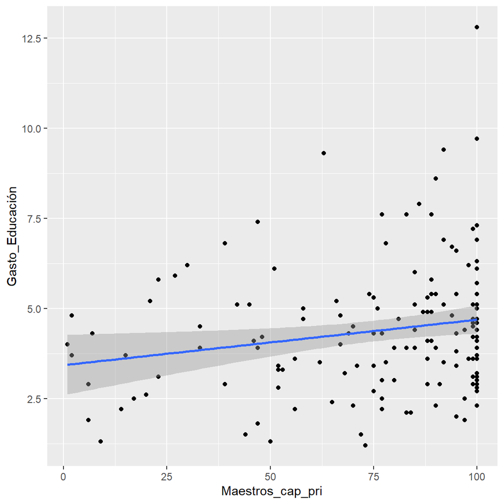

```r
##Plano de primer dimensional

library(ggplot2)

ggplot(Avance1, aes(x=Maestros_cap_pri, y=Gasto_Educación)) +
  geom_point()+
  geom_smooth(method=lm)
```

###2. Hipótesis 2: Los maestros capactiados y la tasa de finalización de la educación de nivel primario son dependientes o afectan al gasto educación total en PIB

```r
modelo2 = formula(Avance1$Gasto_Educación ~  Avance1$Maestros_cap_pri + Avance1$Tasa_finalizar_pri, data=Avance1)

reg2=lm(modelo2,data=Avance1)

summary(reg2)
```

```
##
## Call:
## lm(formula = modelo2, data = Avance1)
##
## Residuals:
##     Min      1Q  Median      3Q     Max
## -3.3032 -1.1735 -0.2440  0.7879  8.0822
##
## Coefficients:
##                            Estimate Std. Error t value Pr(>|t|)
## (Intercept)                2.757088   0.736433   3.744 0.000259 ***
## Avance1$Maestros_cap_pri   0.010977   0.005488   2.000 0.047294 *
## Avance1$Tasa_finalizar_pri 0.009085   0.008190   1.109 0.269144
## ---
## Signif. codes:  0 '***' 0.001 '**' 0.01 '*' 0.05 '.' 0.1 ' ' 1
##
## Residual standard error: 1.791 on 148 degrees of freedom
## Multiple R-squared:  0.04466,    Adjusted R-squared:  0.03175
## F-statistic:  3.46 on 2 and 148 DF,  p-value: 0.03401
```

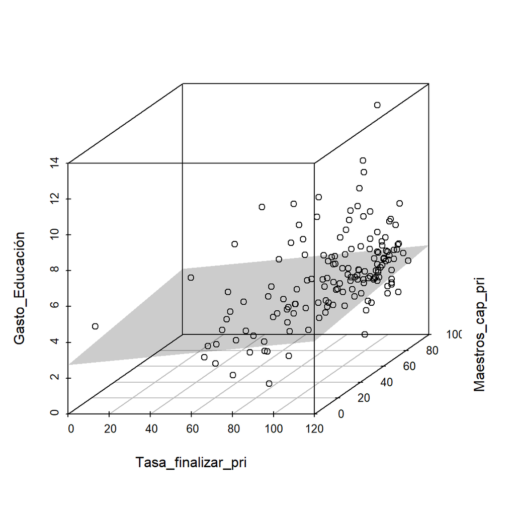

```r
##Plano de tercera dimensión

library(scatterplot3d)
G  <- scatterplot3d(Avance1[,c('Tasa_finalizar_pri','Maestros_cap_pri','Gasto_Educación')])
G$plane3d(reg2, draw_polygon = TRUE, draw_lines = FALSE)
```

```r
library(stargazer)
stargazer(reg2,type = "text",intercept.bottom = FALSE)
```

```
##
## ===============================================
##                         Dependent variable:
##                     ---------------------------
##                           Gasto_Educación
## -----------------------------------------------
## Constant                     2.757***
##                               (0.736)
##
## Maestros_cap_pri              0.011**
##                               (0.005)
##
## Tasa_finalizar_pri             0.009
##                               (0.008)
##
## -----------------------------------------------
## Observations                    151
## R2                             0.045
## Adjusted R2                    0.032
## Residual Std. Error      1.791 (df = 148)
## F Statistic            3.460** (df = 2; 148)
## ===============================================
## Note:               *p<0.1; **p<0.05; ***p<0.01
```

#Dicho esto, se presenta la siguiente ecuaciÃ³n: Y = 2,757088 + 0,010977(X1) + 0,009085(X2))

```
##
## ===============================================================
##                                 Dependent variable:
##                     -------------------------------------------
##                                   Gasto_Educación
##                              (1)                   (2)
## ---------------------------------------------------------------
## Maestros_cap_pri           0.013**               0.011**
##                            (0.005)               (0.005)
##
## Tasa_finalizar_pri                                0.009
##                                                  (0.008)
##
## Constant                  3.426***              2.757***
##                            (0.423)               (0.736)
##
## ---------------------------------------------------------------
## Observations                 151                   151
## R2                          0.037                 0.045
## Adjusted R2                 0.030                 0.032
## Residual Std. Error   1.793 (df = 149)      1.791 (df = 148)
## F Statistic         5.680** (df = 1; 149) 3.460** (df = 2; 148)
## ===============================================================
## Note:                               *p<0.1; **p<0.05; ***p<0.01
```

## ANALISIS DE VARIANZA

A continuaciÃ³n, se analiza si hay un cambio significativo entre el paso del modelo 1 al 2.

H0: Ambos modelos no difieren. H1: Ambos modelos si difieren.

```
##
## Table de AnÃ¡lisis de Varianza
## ===========================================
##   Res.Df   RSS   Df Sum of Sq   F   Pr(> F)
## -------------------------------------------
## 1  149   478.806
## 2  148   474.859 1    3.947   1.230  0.269
## -------------------------------------------
```

###Ho: Cambio No significativo. Quedarse con este es que la variable que viene no aporta. ###H1: Cambio Sí significativo. Si es menor que 0.05; esto quiere decir que la variable que se agrega debería quedarse.

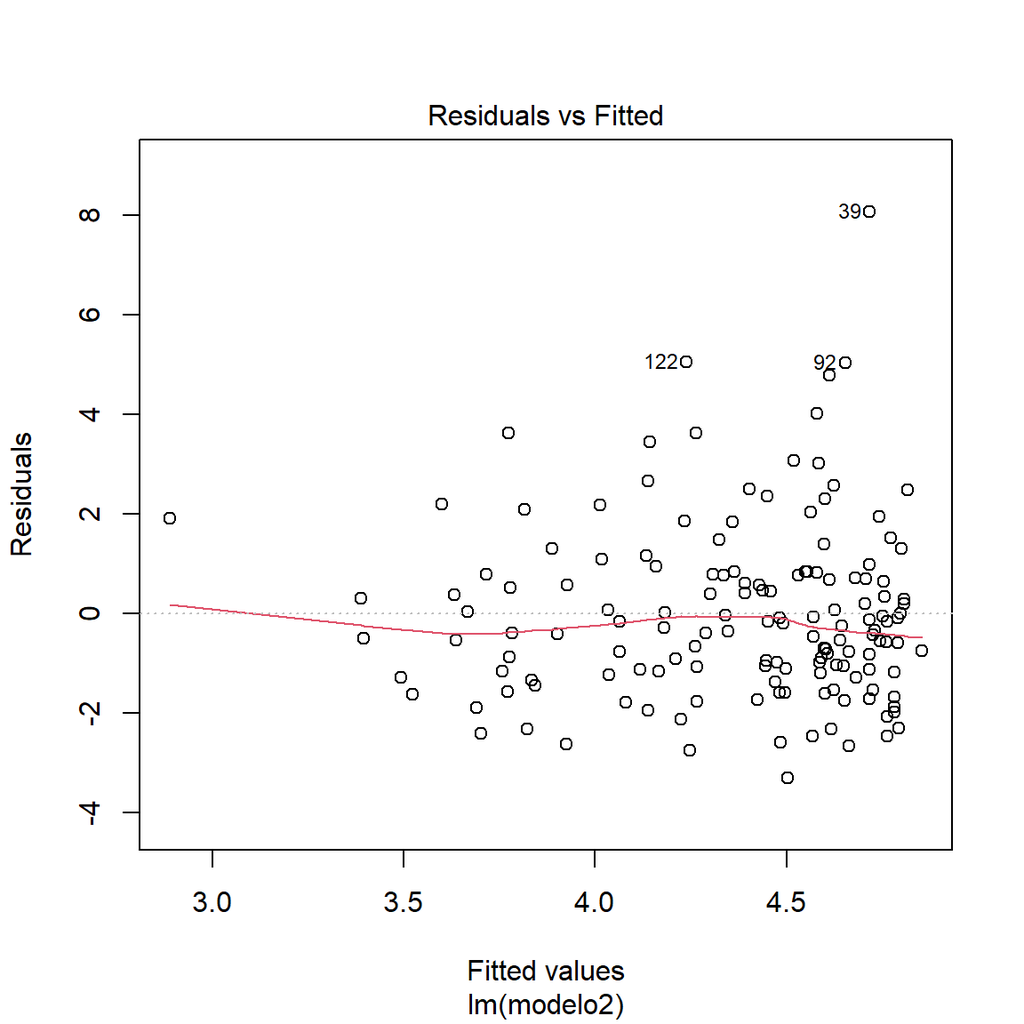

```r
##DIAGNOSTICO DE REGRESION:

#1. Linealidad:

plot(reg2, 1) #línea roja debe tender a la horizonal
```

#Lo principal es que la línea roja esta medianamente horizontal, lo cual demuestra que la linealidad es correcta. El supuesto de linealidad se estÃ¡ cumpliendo.

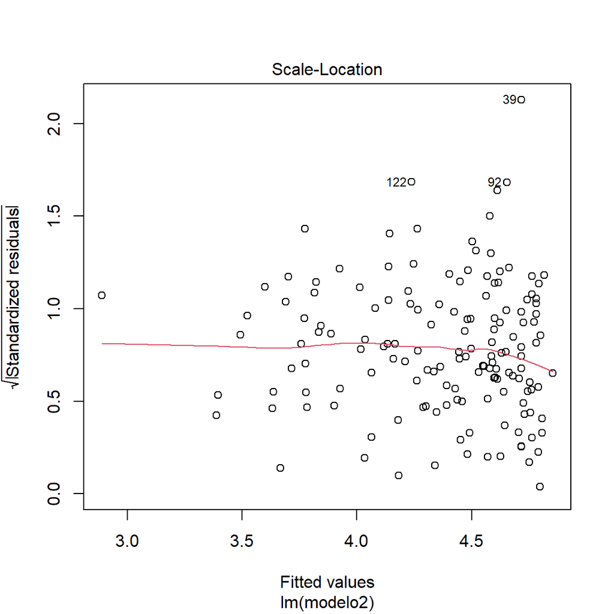

```r
#2. Homocedasticidad

plot(reg2, 3) # linea roja debe tender a horizontal
```

#El modelo si es bueno el Y deberia ser similar al Y residual. El error debe ser muy cercano a 0.

```r
#VerificaciÃ³n

library(lmtest)
bptest(reg2)
```

```
##
##  studentized Breusch-Pagan test
##
## data:  reg2
## BP = 1.8728, df = 2, p-value = 0.392
```

#Ho: Homogeneidad #H1: No hay homogeneidad

#Usando el lmtest se demuestra que hay homogeneidad. Entonces este diagnostico vÃ¡lido porque es mayor a 0.05 y por lo tanto sí hay homocedasticidad.

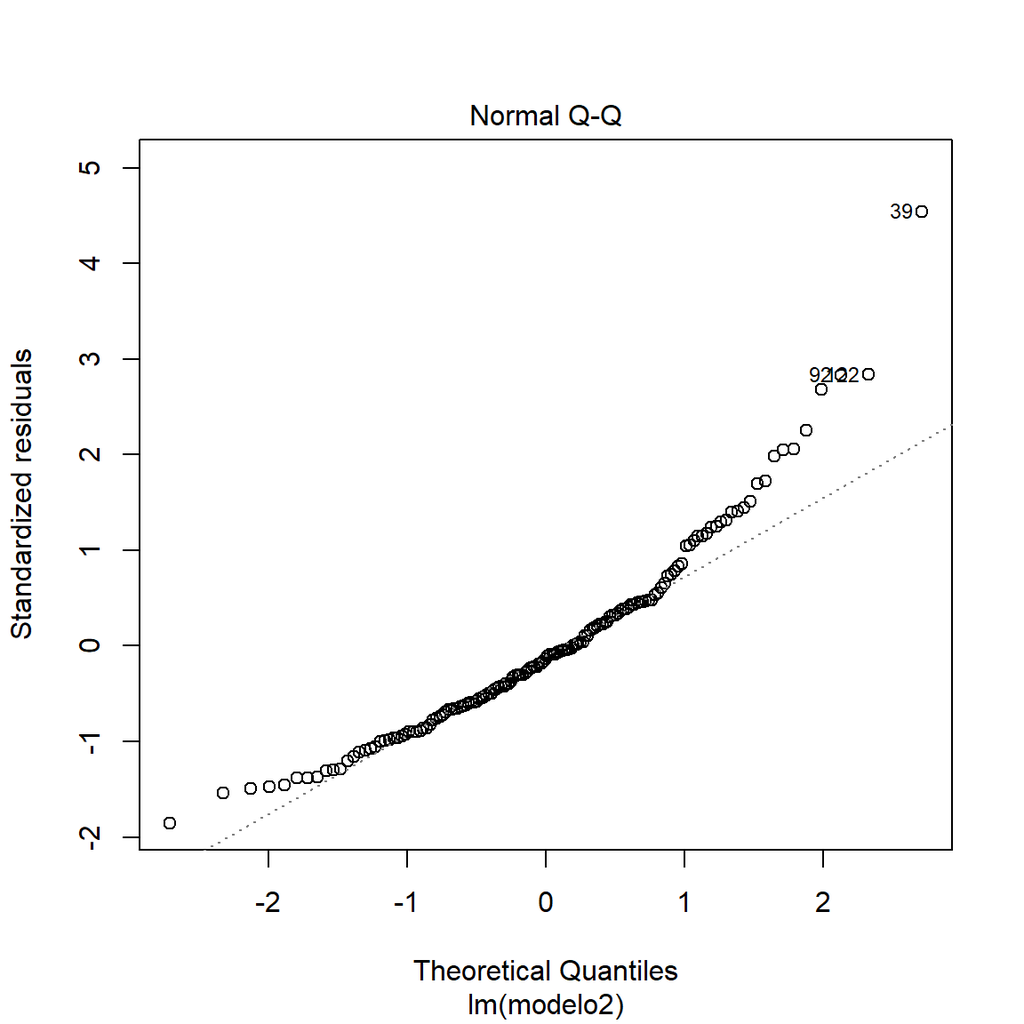

```r
#3. Normalidad de los residuos
plot(reg2, 2)
```

```r
#Verificación


shapiro.test(reg2$residuals)
```

```
##
##  Shapiro-Wilk normality test
##
## data:  reg2$residuals
## W = 0.93306, p-value = 1.52e-06
```

#Ho: Hay normalidad #H1: No hay normalidad

```r
#4. NO MULTICOLINEALIDAD

library(DescTools)
VIF(reg2)
```

```
##   Avance1$Maestros_cap_pri Avance1$Tasa_finalizar_pri
##                   1.077477                   1.077477
```

#Entonces concluimos una contradicción, pero tenemos diferentes herramientas. Tenemos entonces homogeneidad y no hay normalidad de residuos. Luego usamos la no multicolinealidad, pero no debemos eliminar ningún valor.

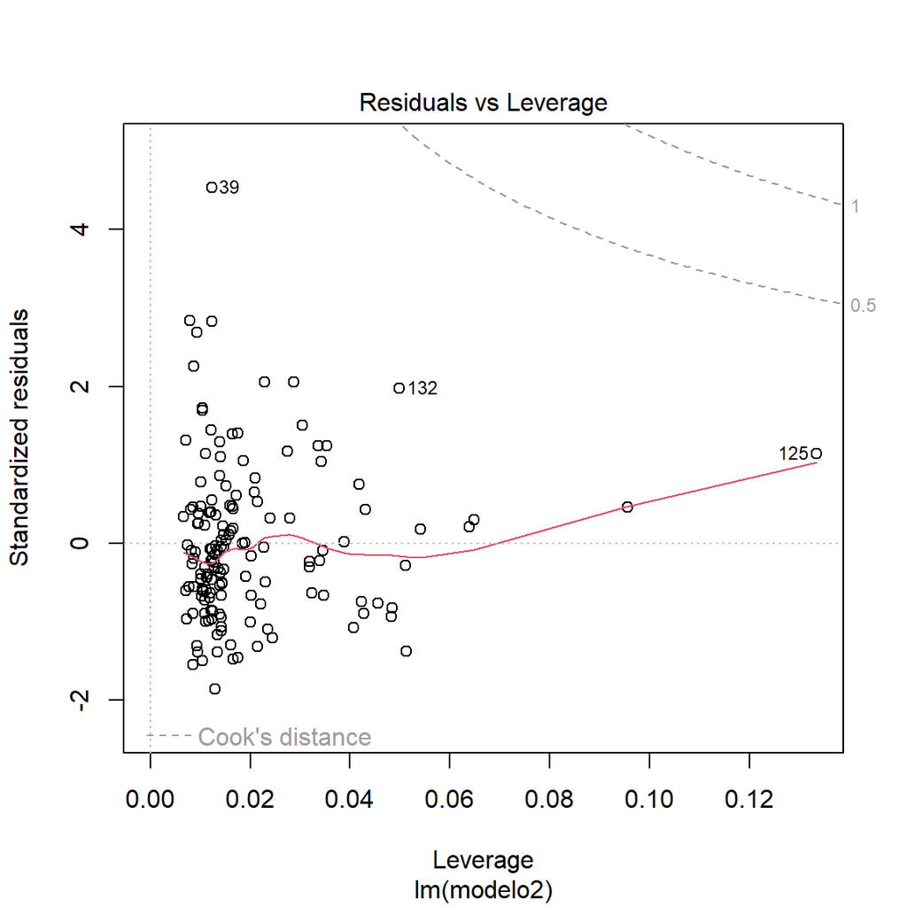

```r
#5. Valores influyentes:

plot(reg2, 5)
```

```r
checkReg2=as.data.frame(influence.measures(reg2)$is.inf)
head(checkReg2)
```

```
##   dfb.1_ dfb.A1$M dfb.A1$T dffit cov.r cook.d   hat
## 1  FALSE    FALSE    FALSE FALSE FALSE  FALSE FALSE
## 2  FALSE    FALSE    FALSE FALSE FALSE  FALSE FALSE
## 3  FALSE    FALSE    FALSE FALSE FALSE  FALSE FALSE
## 4  FALSE    FALSE    FALSE FALSE FALSE  FALSE FALSE
## 5  FALSE    FALSE    FALSE FALSE FALSE  FALSE FALSE
## 6  FALSE    FALSE    FALSE FALSE FALSE  FALSE FALSE
```

```r
checkReg2[checkReg2$cook.d & checkReg2$hat,]
```

```
## [1] dfb.1_   dfb.A1$M dfb.A1$T dffit    cov.r    cook.d   hat
## <0 rows> (or 0-length row.names)
```

#Ambas tienen que ser verdaderas, pero no hay. A nivel de filas. Asimismo, no se tiene que eliminar ningún caso. Todos están bien. No hay que borrar nada.

# ANEXO 2: ANÁLISIS DE CLUSTERS

## LIMPIEZA:

```r
str(TRABAJO_1)
```

```
## tibble [179 × 7] (S3: tbl_df/tbl/data.frame)
##  $ PAISES         : chr [1:179] "Afghanistan" "Albania" "Algeria" "Angola" ...
##  $ Gasto_Edu_Total: num [1:179] 3.2 3.9 6.1 1.8 3.3 4.8 2.7 5.1 5.2 2.7 ...
##  $ Gasto_Edu_Pri  : num [1:179] 84 101 104 46 96 99 93 88 99 100 ...
##  $ Gasto_Edu_Sec  : num [1:179] 68 90 100 47 53 67 75 42 85 100 ...
##  $ Indice_Gini    : num [1:179] NA 33.2 27.6 51.3 NA ...
##  $ PBI            : num [1:179] 67375 33190 4030399 185966 1756334 ...
##  $ Public Services: num [1:179] 9.8 4.4 5.6 9.3 4.4 4.8 3.9 2.8 2.3 5.5 ...
```

#Ya estan en númericas

```r
library(BBmisc)
TRABAJO_1[,-1]=BBmisc::normalize(TRABAJO_1[,-1],method='standardize')
TRABAJO_1=TRABAJO_1[complete.cases(TRABAJO_1),]
```

###1. Proceso de normalización de las variables

```r
##Se presentan los estadísticos descríptivos para cada variable

cor(TRABAJO_1[,-1])
```

```
##                 Gasto_Edu_Total Gasto_Edu_Pri Gasto_Edu_Sec Indice_Gini
## Gasto_Edu_Total      1.00000000    0.12281413    0.20660545 -0.15595798
## Gasto_Edu_Pri        0.12281413    1.00000000    0.27016084 -0.17255106
## Gasto_Edu_Sec        0.20660545    0.27016084    1.00000000 -0.19430245
## Indice_Gini         -0.15595798   -0.17255106   -0.19430245  1.00000000
## PBI                  0.06876577    0.03626317    0.12184526 -0.06519395
## Public Services     -0.18924260   -0.30599773   -0.04887559  0.43102648
##                         PBI Public Services
## Gasto_Edu_Total  0.06876577     -0.18924260
## Gasto_Edu_Pri    0.03626317     -0.30599773
## Gasto_Edu_Sec    0.12184526     -0.04887559
## Indice_Gini     -0.06519395      0.43102648
## PBI              1.00000000     -0.07181368
## Public Services -0.07181368      1.00000000
```

```r
TRABAJO_1$Indice_Gini=-1*TRABAJO_1$Indice_Gini
TRABAJO_1$`Public Services`=-1*TRABAJO_1$`Public Services`
```

```r
BASE=TRABAJO_1[,-1]
row.names(BASE)=TRABAJO_1$PAISES
library(cluster)
g.dist = daisy(BASE, metric="gower")
```

```r
#COPIAS:

DATA_2 = BASE
DATA_3 = BASE
DATA_4 = BASE
```

##2. Proponer cantidad de clusters:

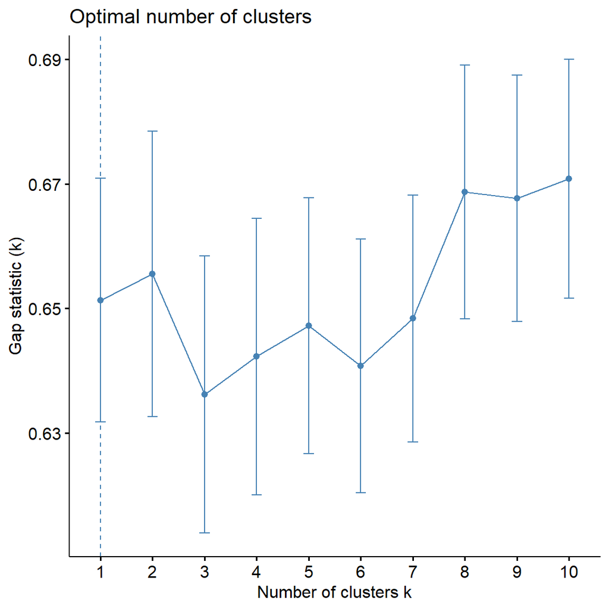

```r
## Para PAM / PARTICIÓN

library(factoextra)
fviz_nbclust(BASE, pam,diss=g.dist,method = "gap_stat",k.max = 10,verbose = F)
```

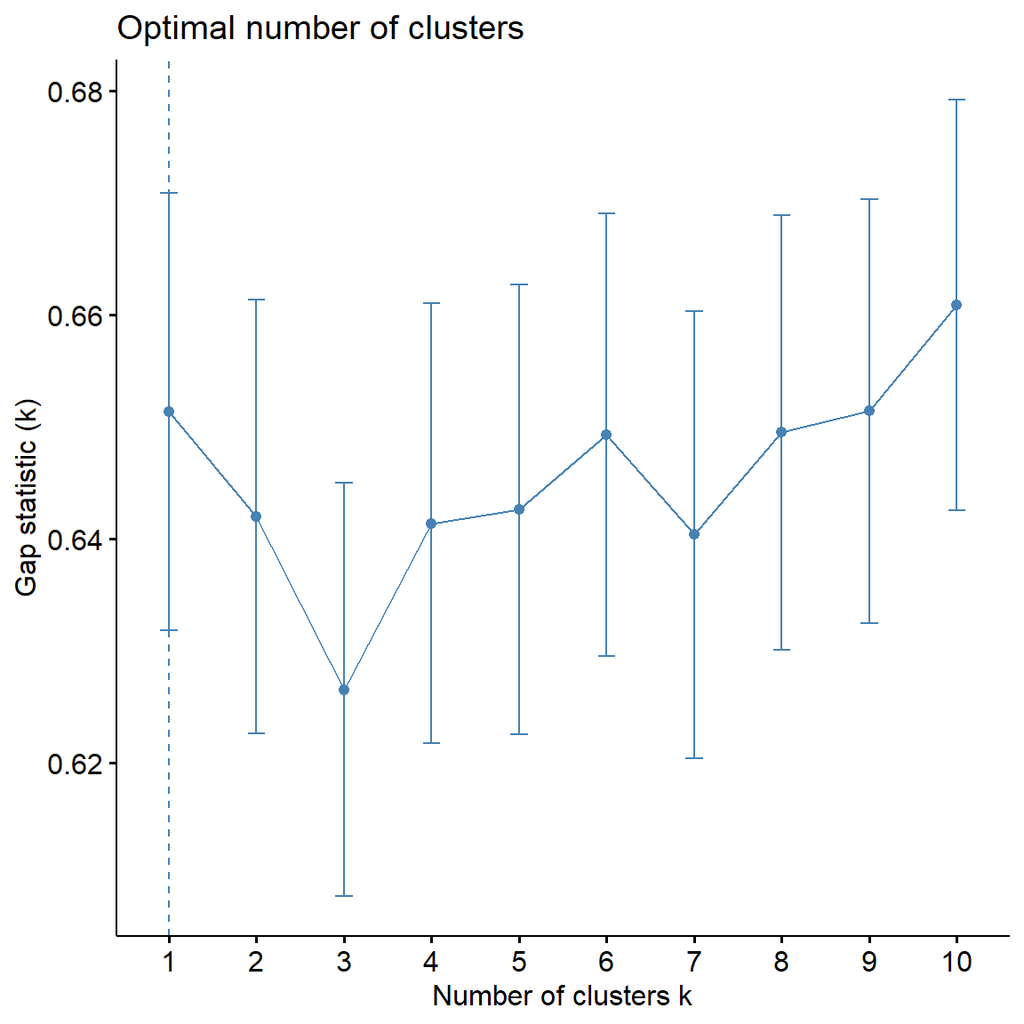

```r
## PARA Agnes

fviz_nbclust(BASE, hcut,diss=g.dist,method = "gap_stat",k.max = 10,verbose = F,hc_func = "agnes")
```

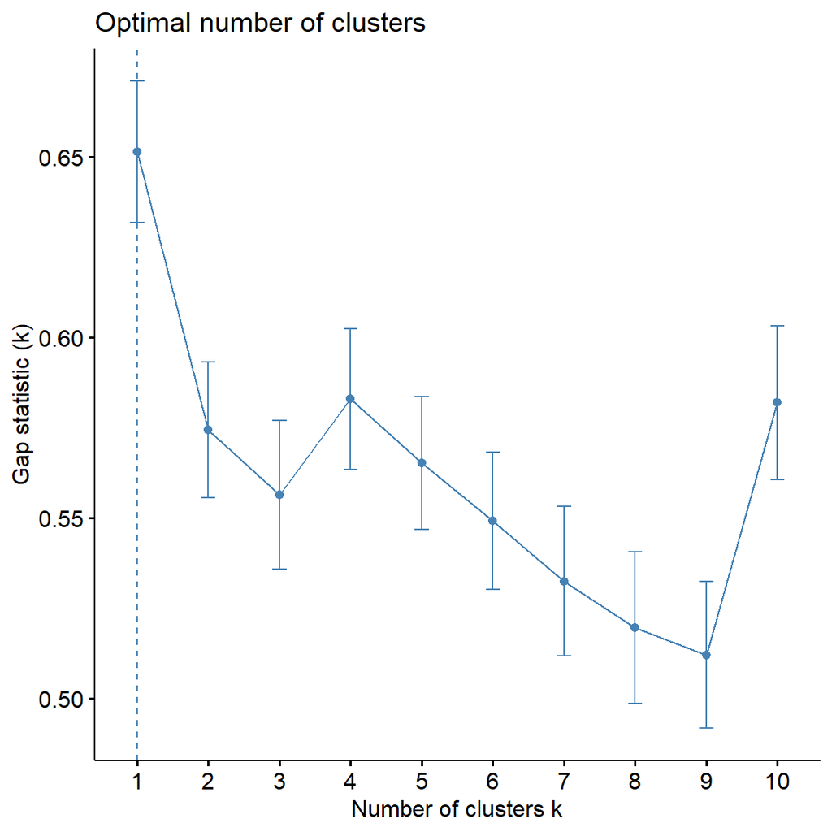

```r
## PARA DIANA

fviz_nbclust(BASE, hcut,diss=g.dist,method = "gap_stat",k.max = 10,verbose = F,hc_func = "diana")
```

##3. Evaluemos resultados ###Pidamos dos grupos porque la cantidad de clusters nos muestra entre 1 o 2:

```r
###pam

set.seed(123)
grupos=2
res.pam=pam(g.dist,k = grupos,cluster.only = F)
DATA_2$pam=res.pam$cluster
```

```r
###agnes

res.agnes<- hcut(g.dist, k =grupos,hc_func='agnes',hc_method = "ward.D")
DATA_3$agnes=res.agnes$cluster
```

```r
###diana

res.diana <- hcut(g.dist, k = grupos,hc_func='diana')
DATA_4$diana=res.diana$cluster
```

##Ahora veamos a cuál le fue mejor:

##a) Para PAN

```
##   cluster size ave.sil.width
## 1       1   67          0.32
## 2       2   67          0.17
```

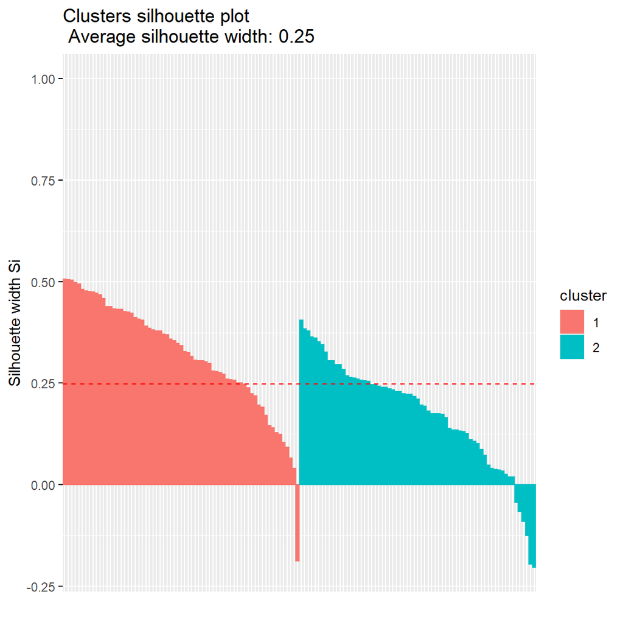

```r
fviz_silhouette(res.pam)
```

##b) Para AGNES

```
##   cluster size ave.sil.width
## 1       1   94          0.34
## 2       2   40          0.20
```

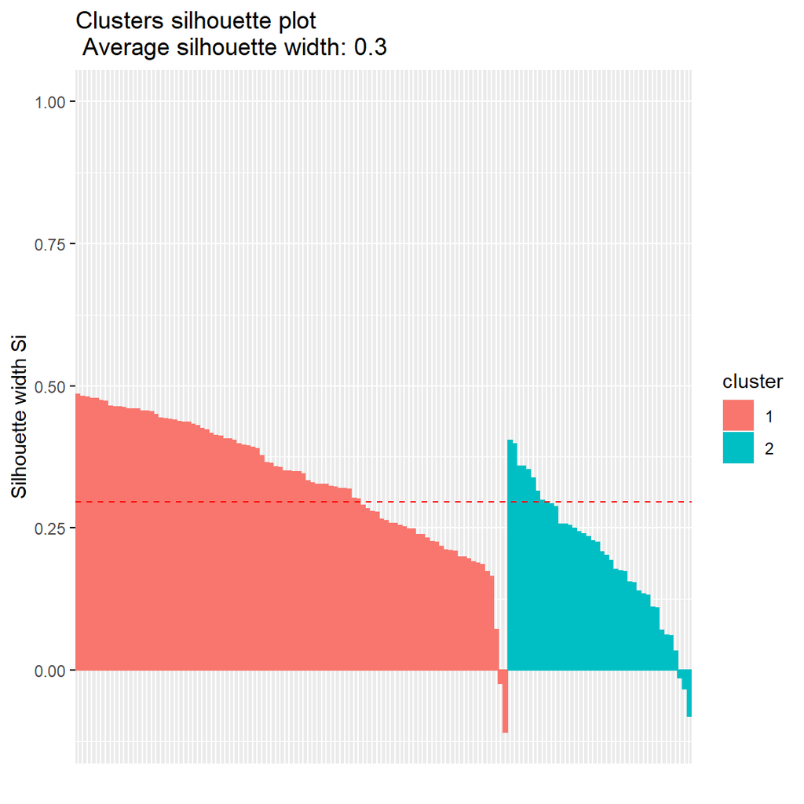

```r
fviz_silhouette(res.agnes)
```

##c) Para DIANA

```
##   cluster size ave.sil.width
## 1       1   96          0.34
## 2       2   38          0.22
```

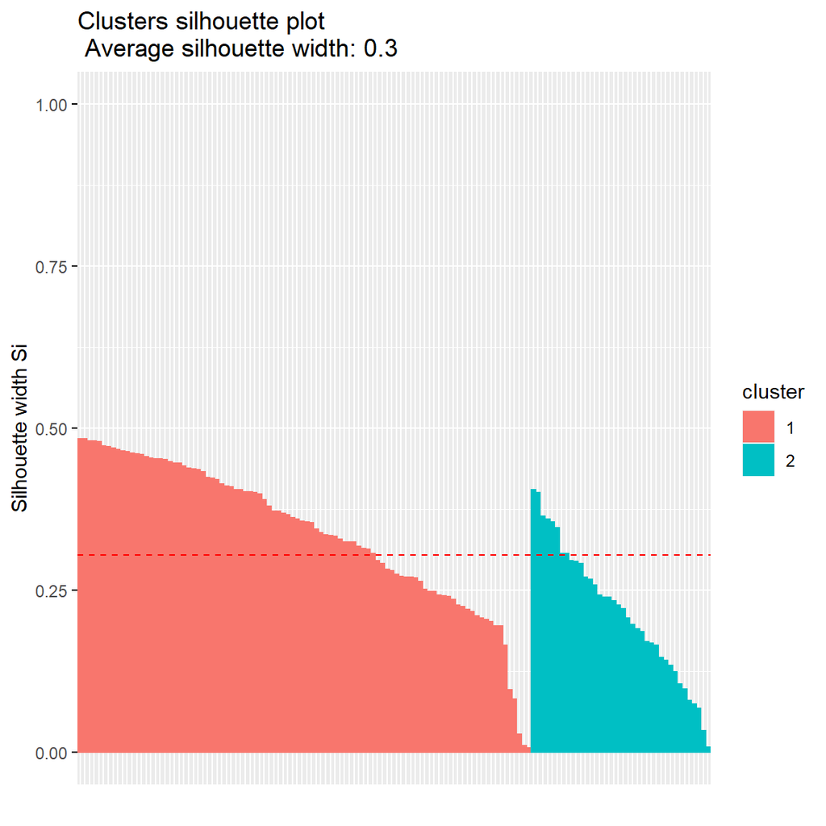

```r
fviz_silhouette(res.diana)
```

```r
##Encontremos los casos MAL clusterizados (silueta negativa):

library(magrittr)

silPAM=data.frame(res.pam$silinfo$widths)
silPAM$country=row.names(silPAM)
poorPAM=silPAM[silPAM$sil_width<0,'country']%>%sort()
```